# ModelEvolvR Introduction

## Explore the Results

The *ModelEvolvR::evolve* function returns a list of three objects, the first object is a list of the final population (i.e., a list of formulas), the second is the corresponding fitness of each model in the final population (a vector), and the third is a vector of the mean population fitness with consecutive generations. Below is an example of these results can be applied and plotted. While the model performance is not outstanding, the algorithm does seem to have selected an important subset of inputs with regard to predicting musical origin.

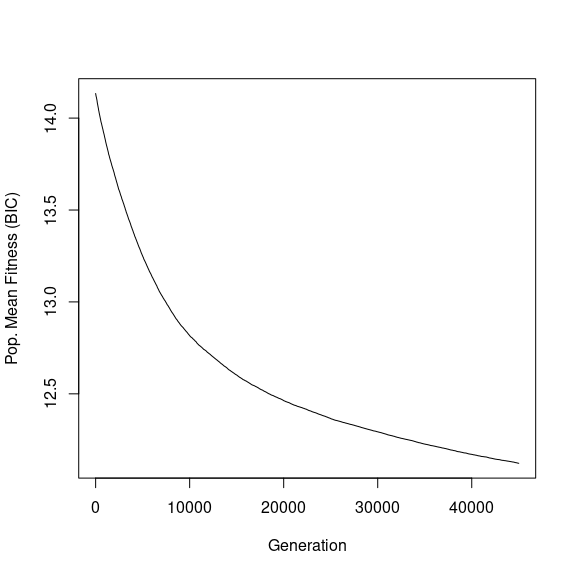

```r
#Plot mean population with consecutive generations
plot(evolved[[3]], type='l', xlab="Generation",ylab = "Pop. Mean Fitness (BIC)")
```

```r
#Get the 'best_modl' based on fitness score, this will only return the first if there are ties
best_model<-evolved[[1]][[which.min(evolved[[2]])]]
best_model
```

```
#> lat ~ V36 + V24 + V32 + V62 + V100 + V93
#> <environment: 0x55d659d669a0>
```

```r
#Get a training data.frame based on GA output FORMULA
train_x <- within(model.frame(as.formula(best_model),train_df),rm(lat))

#Fit the KNN on the training data
fit <- knnreg(train_x,train_df$lat, k = 15)

#Get the test data.frame based on GA output FORMULA
test_x <- within(model.frame(as.formula(best_model),test_df),rm(lat))

mae = mean(abs(train_df$lat-predict(fit,train_x)))
mae
```

```
#> [1] 12.84541
```

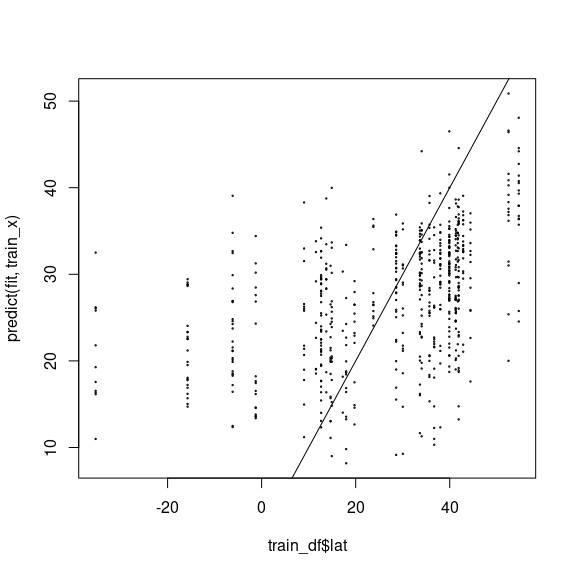

```r
plot(train_df$lat,predict(fit,train_x),cex=0.2)
abline(a=0,b=1)
```

```r
#Determine the MAE of the KNN model on the test dataframe
mae = mean(abs(test_df$lat-predict(fit,test_x)))
mae
```

```
#> [1] 12.57048
```

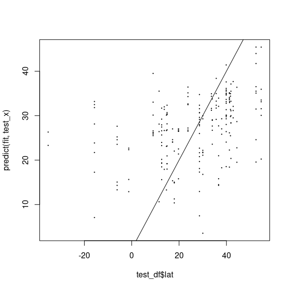

```r
plot(test_df$lat,predict(fit,test_x),cex=0.2)
abline(a=0,b=1)
```

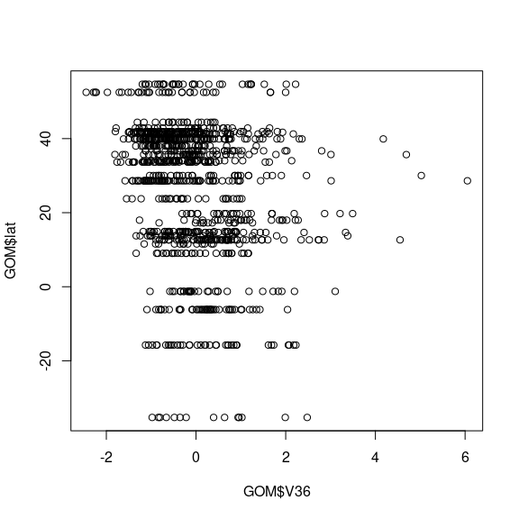

```r
plot(GOM$V36,GOM$lat)
```

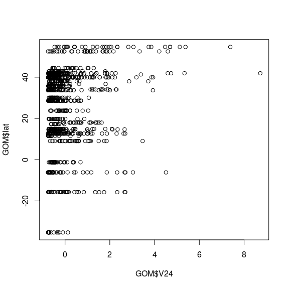

```r
plot(GOM$V24,GOM$lat)
```

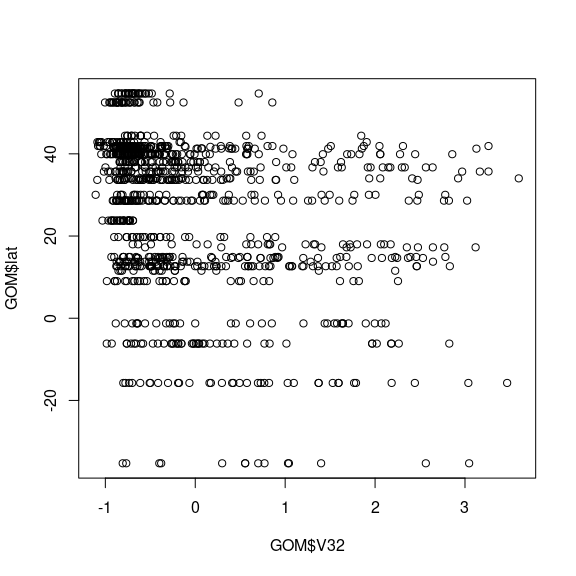

```r
plot(GOM$V32,GOM$lat)
```

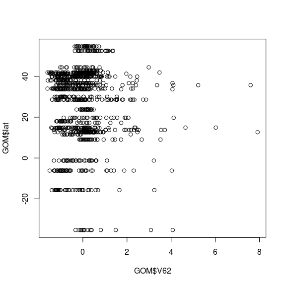

```r
plot(GOM$V62,GOM$lat)
```

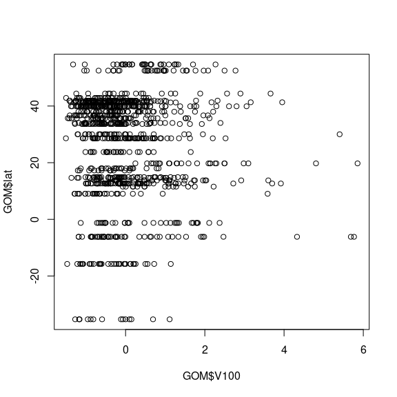

```r
plot(GOM$V100,GOM$lat)
```

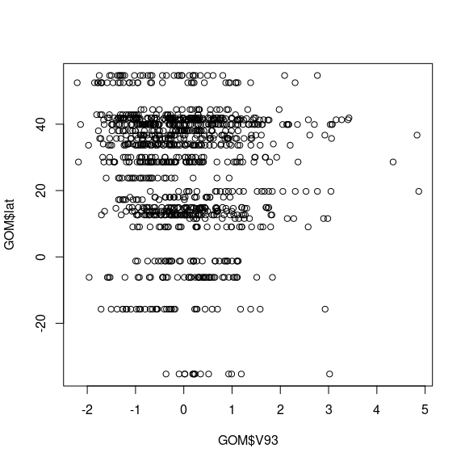

```r
plot(GOM$V93,GOM$lat)
```

## Adding interactions

Interaction terms can be added before running GA by adding their tags to **x_names** in formula syntax, for example:

```r
iters<-c()
cnt<-1
for(i in c(1:length(x_names)))
{
  for(j in c(i:length(x_names)))
  {
    iters[cnt]<-paste(x_names[i],":",x_names[j],sep="")
    cnt<-cnt+1
  }
}

iters<-c(x_names,iters)

tail(iters)
```

```
#> [1] "V114:V114" "V114:V115" "V114:V116" "V115:V115" "V115:V116" "V116:V116"
```

```r
x_names <- iters
```